# Classification report

### ROC AUC analysis

```r
all_features_data <- roc_auc_data %>%
  filter(feat_group == "all") %>%
  filter(agg_level != "all")

roc_auc_cancer_stats <- all_features_data %>%
  group_by(cancer_type) %>%
  summarize(
    min_test_auc = min(te_auc),
    sd_test_auc = sd(te_auc),
    test_auc = median(te_auc),
    test_auc_mean = mean(te_auc),
    n_auc = n(),
    train_auc = median(tr_auc)
  )

roc_auc_cancer_stats %>%
  arrange(min_test_auc)
```

| cancer_type | min_test_auc | sd_test_auc | test_auc | test_auc_mean | n_auc | train_auc |
| --- | --- | --- | --- | --- | --- | --- |
| bone | 0.4586472 | 0.05412830 | 0.6174969 | 0.6343396 | 90 | 0.7030204 |
| blood | 0.4964396 | 0.07758211 | 0.5923056 | 0.6131140 | 90 | 0.6943755 |
| skin | 0.5237268 | 0.05317318 | 0.6059743 | 0.6208747 | 90 | 0.7010642 |
| liver | 0.5372950 | 0.08139701 | 0.6622055 | 0.6866215 | 90 | 0.7195825 |
| ovary | 0.5578150 | 0.04780226 | 0.6766229 | 0.6733690 | 90 | 0.7458685 |
| brain | 0.5579831 | 0.07551307 | 0.6674510 | 0.6788180 | 90 | 0.7631237 |
| pancreatic | 0.5697551 | 0.07617244 | 0.6688531 | 0.6865037 | 90 | 0.7392077 |
| uterus | 0.5716303 | 0.05172510 | 0.6512527 | 0.6549767 | 90 | 0.7557218 |
| prostate | 0.5924576 | 0.05129807 | 0.6862194 | 0.6921507 | 90 | 0.7723043 |
| breast | 0.6766782 | 0.06482134 | 0.7984719 | 0.7930374 | 90 | 0.8432920 |

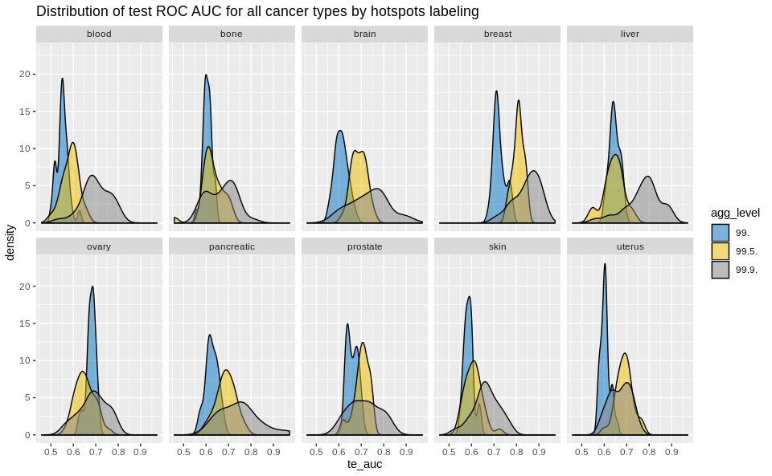

```r
ggplot(all_features_data, aes(te_auc, fill=agg_level)) +
  geom_density(alpha=0.5)+
  facet_wrap(~ cancer_type, nrow = 2) +
  ggtitle("Distribution of test ROC AUC for all cancer types by hotspots labeling") +
  scale_fill_jco()
```

```r
NA
```

Difference between train and test

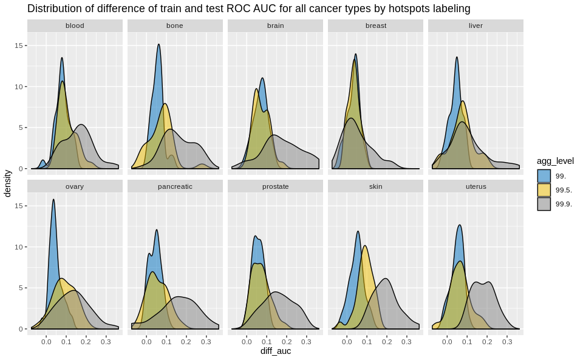

```r
all_features_data$diff_auc <- all_features_data$tr_auc - all_features_data$te_auc
ggplot(all_features_data, aes(diff_auc, fill=agg_level)) +
  geom_density(alpha=0.5)+
  facet_wrap(~ cancer_type, nrow = 2) +
  ggtitle("Distribution of difference of train and test ROC AUC for all cancer types by hotspots labeling") +
  scale_fill_jco()
```

```r
NA
```

Minimal test ROC AUC for each cancer type and labeling.

```r
by_hspt_min <- by_hspt %>%
  select(cancer_type, agg_level, min_test_auc, test_auc, train_test_diff) %>%
  dcast(formula = cancer_type ~ agg_level, value.var = "min_test_auc")
names(by_hspt_min)[2:ncol(by_hspt_min)] <- paste0("min_test_", names(by_hspt_min)[2:ncol(by_hspt_min)])

formattable(by_hspt_min, align =c("l","c","c","c"), list(
  `cancer_type` = formatter("span", style = ~ style(color = "grey", font.weight = "bold")),
  `min_test_99.`= color_tile('#1E90FF', 'yellow'),
  `min_test_99.5.`= color_tile('#1E90FF', 'yellow'),
  `min_test_99.9.`= color_tile('#1E90FF', 'yellow')
))
```

| cancer_type | min_test_99. | min_test_99.5. | min_test_99.9. |
| --- | --- | --- | --- |
| blood | 0.5013305 | 0.4964396 | 0.5331836 |
| bone | 0.5575007 | 0.4586472 | 0.5707468 |
| brain | 0.5579831 | 0.6170378 | 0.5728645 |
| breast | 0.6766782 | 0.7550462 | 0.7053378 |
| liver | 0.6023007 | 0.5372950 | 0.5587976 |
| ovary | 0.6234314 | 0.5701192 | 0.5578150 |
| pancreatic | 0.5697551 | 0.5915867 | 0.5985340 |
| prostate | 0.6264322 | 0.6134076 | 0.5924576 |
| skin | 0.5486692 | 0.5484350 | 0.5237268 |
| uterus | 0.5716303 | 0.5989549 | 0.5881787 |

Median test ROC AUC for each cancer type and labeling.

```r
by_hspt_med <- by_hspt %>%
  select(cancer_type, agg_level, min_test_auc, test_auc, train_test_diff) %>%
  dcast(formula = cancer_type ~ agg_level, value.var = "test_auc")
names(by_hspt_med)[2:ncol(by_hspt_med)] <- paste0("median_test_", names(by_hspt_med)[2:ncol(by_hspt_med)])

formattable(by_hspt_med, align =c("l","c","c","c"), list(
  `cancer_type` = formatter("span", style = ~ style(color = "grey", font.weight = "bold")),
  `median_test_99.`= color_tile('#1E90FF', 'yellow'),
  `median_test_99.5.`= color_tile('#1E90FF', 'yellow'),
  `median_test_99.9.`= color_tile('#1E90FF', 'yellow')
))
```

| cancer_type | median_test_99. | median_test_99.5. | median_test_99.9. |
| --- | --- | --- | --- |
| blood | 0.5519007 | 0.5930396 | 0.6932266 |
| bone | 0.6055714 | 0.6214577 | 0.6726514 |
| brain | 0.6116738 | 0.6891983 | 0.7495539 |
| breast | 0.7149460 | 0.8099490 | 0.8608401 |
| liver | 0.6447062 | 0.6459147 | 0.7843401 |
| ovary | 0.6839834 | 0.6477968 | 0.6834700 |
| pancreatic | 0.6245708 | 0.6885219 | 0.7517185 |
| prostate | 0.6590672 | 0.7056549 | 0.7173045 |
| skin | 0.5870175 | 0.6071970 | 0.6675829 |
| uterus | 0.6027628 | 0.6886627 | 0.6801932 |

```r
by_hspt_med <- by_hspt %>%
  select(cancer_type, agg_level, min_test_auc, test_auc, train_test_diff) %>%
  dcast(formula = cancer_type ~ agg_level, value.var = "test_auc")
names(by_hspt_med)[2:ncol(by_hspt_med)] <- paste0("median_test_", names(by_hspt_med)[2:ncol(by_hspt_med)])
```

Difference between train and test ROC AUC for each cancer type and labeling.

```r
by_hspt_diff <- by_hspt %>%
  select(cancer_type, agg_level, min_test_auc, test_auc, train_test_diff) %>%
  dcast(formula = cancer_type ~ agg_level, value.var = "train_test_diff")
names(by_hspt_diff)[2:ncol(by_hspt_diff)] <- paste0("diff_", names(by_hspt_diff)[2:ncol(by_hspt_diff)])

formattable(by_hspt_diff, align =c("l","c","c","c"), list(
  `cancer_type` = formatter("span", style = ~ style(color = "grey", font.weight = "bold")),
  `diff_99.`= color_tile('#1E90FF', 'yellow'),
  `diff_99.5.`= color_tile('#1E90FF', 'yellow'),
  `diff_99.9.`= color_tile('#1E90FF', 'yellow')
))
```

| cancer_type | diff_99. | diff_99.5. | diff_99.9. |
| --- | --- | --- | --- |
| blood | 0.08077486 | 0.10453884 | 0.15952136 |
| bone | 0.05566227 | 0.07341312 | 0.16222598 |
| brain | 0.06904775 | 0.07324804 | 0.17837874 |
| breast | 0.03188523 | 0.03537544 | 0.05086416 |
| liver | 0.04337602 | 0.07485956 | 0.10175290 |
| ovary | 0.04675491 | 0.09087181 | 0.13567523 |
| pancreatic | 0.04285220 | 0.05535996 | 0.15733020 |
| prostate | 0.05586686 | 0.07147533 | 0.15862986 |
| skin | 0.04891334 | 0.09036062 | 0.19499457 |
| uterus | 0.05008486 | 0.06442701 | 0.18065506 |

```r
by_hspt_diff <- by_hspt %>%
  select(cancer_type, agg_level, min_test_auc, test_auc, train_test_diff) %>%
  dcast(formula = cancer_type ~ agg_level, value.var = "train_test_diff")
names(by_hspt_diff)[2:ncol(by_hspt_diff)] <- paste0("diff_", names(by_hspt_diff)[2:ncol(by_hspt_diff)])
formattable(by_hspt_diff, align =c("l","c","c","c"), list(
  `cancer_type` = formatter("span", style = ~ style(color = "grey", font.weight = "bold")),
  `diff_99.`= color_tile('#1E90FF', 'yellow'),
  `diff_99.5.`= color_tile('#1E90FF', 'yellow'),
  `diff_99.9.`= color_tile('#1E90FF', 'yellow')
))
```

| cancer_type | diff_99. | diff_99.5. | diff_99.9. |
| --- | --- | --- | --- |
| blood | 0.08077486 | 0.10453884 | 0.15952136 |
| bone | 0.05566227 | 0.07341312 | 0.16222598 |
| brain | 0.06904775 | 0.07324804 | 0.17837874 |
| breast | 0.03188523 | 0.03537544 | 0.05086416 |
| liver | 0.04337602 | 0.07485956 | 0.10175290 |
| ovary | 0.04675491 | 0.09087181 | 0.13567523 |
| pancreatic | 0.04285220 | 0.05535996 | 0.15733020 |
| prostate | 0.05586686 | 0.07147533 | 0.15862986 |
| skin | 0.04891334 | 0.09036062 | 0.19499457 |
| uterus | 0.05008486 | 0.06442701 | 0.18065506 |

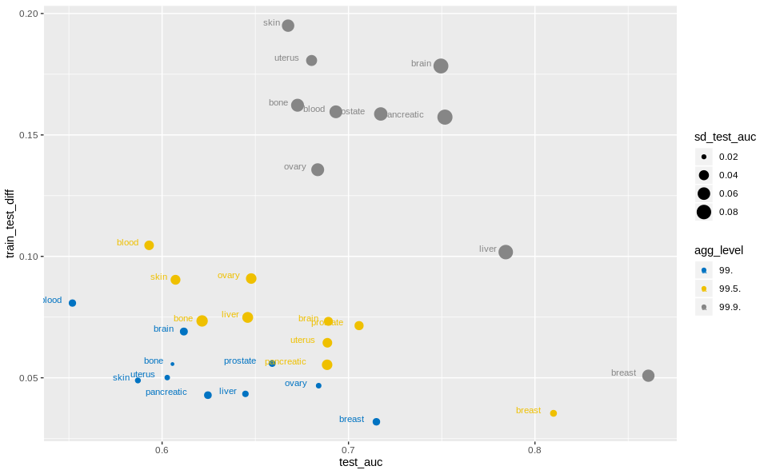

```r
best_lev <- data.frame(
  cancer_type=c("blood", "bone","brain", "breast", "liver","ovary","pancreatic", "prostate","skin", "uterus"),
  agg_level=c("99.5.", "99.5.", "99.5.", "99.9.","99.","99.", "99.5.", "99.5.", "99.5.", "99.5.")
)
```

[output not shown]

Итого: Практически для всех типов рака медиана тестового ROC AUC растет с повышением порога для разметки хотспотов, т.е. мы ранжируем участки лучше, если пытаемся выделить более ярко выраженные хотспоты (меньшее количество). Отсюда гипотеза: Разрывы могут появляться в случайных местах, но есть участки генома, более подверженные (неустойчивые) этому, и их немного.

Интересно: Может и другие разрывы в этих участках? Может это какая-то глобальная неустойчивость (может проверить по другим заболеваниям?)

#### How different feature groups removal effect overall performance

Обратить внимание на разницу в важности фичей между разными типами рака и в одном типе рака для разных agg_level

Preprocess data:

Distribution of test ROC AUC loss

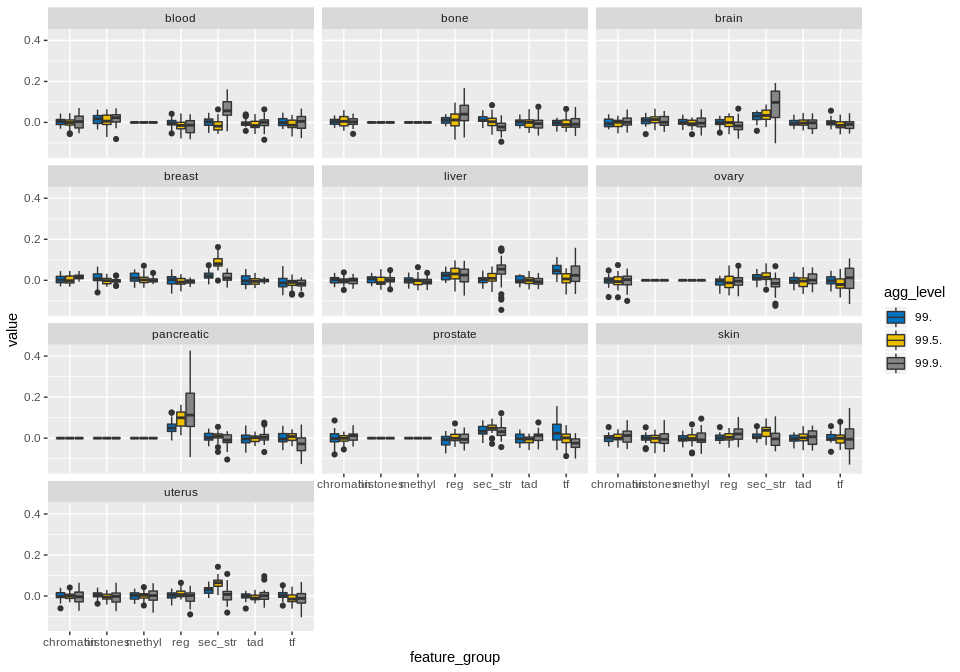

```r
reduced_test_loss_cols <- grep(x = names(all_features_data_full_df), pattern = "reduced_test_loss_", value = T)

reduced_test_df <- all_features_data_full_df %>%
  select(c("cancer_type", "agg_level", reduced_test_loss_cols))
reduced_test_df <- melt(data = reduced_test_df, id.vars = c("cancer_type","agg_level"))
reduced_test_df$feature_group <- as.character(reduced_test_df$variable)
reduced_test_df$feature_group <- gsub(x = reduced_test_df$feature_group,
                                      pattern = "reduced_test_loss_wo_", replacement = "")

ggplot(reduced_test_df, aes(x=feature_group, y=value, fill=agg_level))+
  geom_boxplot() +
  facet_wrap(~ cancer_type, nrow = 4) +
  scale_fill_jco()
```

```r
agg_cancer <- reduced_test_df %>%
  group_by(cancer_type, feature_group) %>%
  summarize(mean_decrease = median(value))
agg_cancer[agg_cancer$mean_decrease == 0, "mean_decrease"] <- NA
agg_cancer <- agg_cancer %>%
    mutate(mean_decrease = round(mean_decrease, 4))

agg_cancer_dcast <- dcast(agg_cancer, formula = cancer_type ~ feature_group, value.var = "mean_decrease")

formattable(agg_cancer_dcast, align =c("l", "c", "c","c","c", "c","c","c"), list(
  `cancer_type` = formatter("span", style = ~ style(color = "grey", font.weight = "bold")),
  `chromatin`= color_tile('#1E90FF', 'yellow'),
  `histones`= color_tile('#1E90FF', 'yellow'),
  `methyl`= color_tile('#1E90FF', 'yellow'),
  `reg`= color_tile('#1E90FF', 'yellow'),
  `sec_str`= color_tile('#1E90FF', 'yellow'),
  `tad`= color_tile('#1E90FF', 'yellow'),
  `tf`= color_tile('#1E90FF', 'yellow')
))
```

| cancer_type | chromatin | histones | methyl | reg | sec_str | tad | tf |
| --- | --- | --- | --- | --- | --- | --- | --- |
| blood | 0.0013 | 0.0176 | NA | -0.0088 | 0.0047 | -0.0054 | -0.0021 |
| bone | 0.0041 | NA | NA | 0.0172 | 0.0034 | -0.0010 | -0.0052 |
| brain | -0.0027 | 0.0075 | -0.0032 | -0.0073 | 0.0365 | -0.0037 | -0.0057 |
| breast | 0.0106 | -0.0004 | 0.0037 | -0.0059 | 0.0344 | -0.0027 | -0.0138 |
| liver | 0.0014 | 0.0010 | -0.0019 | 0.0256 | 0.0139 | -0.0034 | 0.0307 |
| ovary | -0.0006 | NA | NA | -0.0051 | 0.0069 | -0.0019 | -0.0023 |
| pancreatic | NA | NA | NA | 0.0762 | 0.0071 | 0.0030 | -0.0040 |
| prostate | 0.0026 | NA | NA | -0.0046 | 0.0404 | -0.0002 | -0.0043 |
| skin | 0.0021 | -0.0013 | -0.0040 | 0.0067 | 0.0099 | -0.0007 | -0.0042 |
| uterus | -0.0022 | 0.0026 | 0.0030 | 0.0062 | 0.0322 | -0.0028 | -0.0071 |

```r
agg_cancer <- reduced_test_df %>%
  group_by(cancer_type, feature_group) %>%
  summarize(mean_decrease = median(value))
agg_cancer[agg_cancer$mean_decrease == 0, "mean_decrease"] <- NA
agg_cancer <- agg_cancer %>%
    mutate(mean_decrease = round(mean_decrease, 4))
agg_cancer_dcast <- dcast(agg_cancer, formula = cancer_type ~ feature_group, value.var = "mean_decrease")
formattable(agg_cancer_dcast, align =c("l", "c", "c","c","c", "c","c","c"), list(
  `cancer_type` = formatter("span", style = ~ style(color = "grey", font.weight = "bold")),
  `chromatin`= color_tile('#1E90FF', 'yellow'),
  `histones`= color_tile('#1E90FF', 'yellow'),
  `methyl`= color_tile('#1E90FF', 'yellow'),
  `reg`= color_tile('#1E90FF', 'yellow'),
  `sec_str`= color_tile('#1E90FF', 'yellow'),
  `tad`= color_tile('#1E90FF', 'yellow'),
  `tf`= color_tile('#1E90FF', 'yellow')
))
```

| cancer_type | chromatin | histones | methyl | reg | sec_str | tad | tf |
| --- | --- | --- | --- | --- | --- | --- | --- |
| blood | 0.0013 | 0.0176 | NA | -0.0088 | 0.0047 | -0.0054 | -0.0021 |
| bone | 0.0041 | NA | NA | 0.0172 | 0.0034 | -0.0010 | -0.0052 |
| brain | -0.0027 | 0.0075 | -0.0032 | -0.0073 | 0.0365 | -0.0037 | -0.0057 |
| breast | 0.0106 | -0.0004 | 0.0037 | -0.0059 | 0.0344 | -0.0027 | -0.0138 |
| liver | 0.0014 | 0.0010 | -0.0019 | 0.0256 | 0.0139 | -0.0034 | 0.0307 |
| ovary | -0.0006 | NA | NA | -0.0051 | 0.0069 | -0.0019 | -0.0023 |
| pancreatic | NA | NA | NA | 0.0762 | 0.0071 | 0.0030 | -0.0040 |
| prostate | 0.0026 | NA | NA | -0.0046 | 0.0404 | -0.0002 | -0.0043 |
| skin | 0.0021 | -0.0013 | -0.0040 | 0.0067 | 0.0099 | -0.0007 | -0.0042 |
| uterus | -0.0022 | 0.0026 | 0.0030 | 0.0062 | 0.0322 | -0.0028 | -0.0071 |

| cancer_type | feature_group | mean_decrease |
| --- | --- | --- |
| pancreatic | reg | 0.0762 |
| prostate | sec_str | 0.0404 |
| brain | sec_str | 0.0365 |
| breast | sec_str | 0.0344 |
| uterus | sec_str | 0.0322 |
| liver | tf | 0.0307 |
| blood | histones | 0.0176 |
| bone | reg | 0.0172 |
| skin | sec_str | 0.0099 |
| ovary | sec_str | 0.0069 |

Выводы: Видим, что практически для всех типов рака удаление фичей определенной группы не несет сильной потери качества, что вызвано высокой скоррелированностью признаков (смысловая нагрузка переносится на фичи другой группы, которые коррелируют с удаленной, поэтому даже если она важна, потери качества не происходит).

#### Выделение всех разрывов

| cancer_type | min_test_auc | sd_test_auc | test_auc | test_auc_mean | n_auc | train_auc |
| --- | --- | --- | --- | --- | --- | --- |
| blood | 0.4953425 | 0.005945327 | 0.5047958 | 0.5053231 | 30 | 0.5325900 |
| uterus | 0.5005870 | 0.003311019 | 0.5051052 | 0.5056431 | 30 | 0.5094537 |
| bone | 0.5197653 | 0.008625104 | 0.5369643 | 0.5371693 | 30 | 0.5657616 |
| brain | 0.5336645 | 0.010591967 | 0.5585742 | 0.5577653 | 30 | 0.5979650 |
| skin | 0.5456594 | 0.005253592 | 0.5586207 | 0.5581586 | 30 | 0.5663787 |
| liver | 0.5609275 | 0.004923004 | 0.5715445 | 0.5702630 | 30 | 0.5740135 |
| pancreatic | 0.5923070 | 0.006661724 | 0.6041657 | 0.6049647 | 30 | 0.6110022 |
| ovary | 0.6146061 | 0.004097861 | 0.6246016 | 0.6246913 | 30 | 0.6295415 |
| prostate | 0.6844652 | 0.008546898 | 0.6980889 | 0.6963638 | 30 | 0.7040288 |
| breast | 0.7435943 | 0.007459942 | 0.7662055 | 0.7655248 | 30 | 0.7693536 |

Compare with results for hotspots

| cancer_type | breakpoints_min_test_auc | hotspot_min_test_auc | breakpoints_test_auc | hotspot_test_auc |
| --- | --- | --- | --- | --- |
| blood | 0.4953425 | 0.4964396 | 0.5047958 | 0.5930396 |
| bone | 0.5197653 | 0.4586472 | 0.5369643 | 0.6214577 |
| brain | 0.5336645 | 0.6170378 | 0.5585742 | 0.6891983 |
| breast | 0.7435943 | 0.7053378 | 0.7662055 | 0.8608401 |
| liver | 0.5609275 | 0.6023007 | 0.5715445 | 0.6447062 |
| ovary | 0.6146061 | 0.6234314 | 0.6246016 | 0.6839834 |
| pancreatic | 0.5923070 | 0.5915867 | 0.6041657 | 0.6885219 |
| prostate | 0.6844652 | 0.6134076 | 0.6980889 | 0.7056549 |
| skin | 0.5456594 | 0.5484350 | 0.5586207 | 0.6071970 |
| uterus | 0.5005870 | 0.5989549 | 0.5051052 | 0.6886627 |

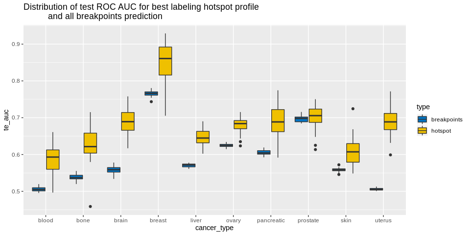

| cancer_type | breakpoints | hotspot | ratio |
| --- | --- | --- | --- |
| prostate | 0.6980889 | 0.7056549 | 1.010838 |
| skin | 0.5586207 | 0.6071970 | 1.086958 |
| ovary | 0.6246016 | 0.6839834 | 1.095071 |
| breast | 0.7662055 | 0.8608401 | 1.123511 |
| liver | 0.5715445 | 0.6447062 | 1.128007 |
| pancreatic | 0.6041657 | 0.6885219 | 1.139624 |
| bone | 0.5369643 | 0.6214577 | 1.157354 |
| blood | 0.5047958 | 0.5930396 | 1.174811 |
| brain | 0.5585742 | 0.6891983 | 1.233853 |
| uterus | 0.5051052 | 0.6886627 | 1.363405 |

### Quality of clasifiers analysis

Aggregated statistics for hotspots prediction by cancer type

Recall

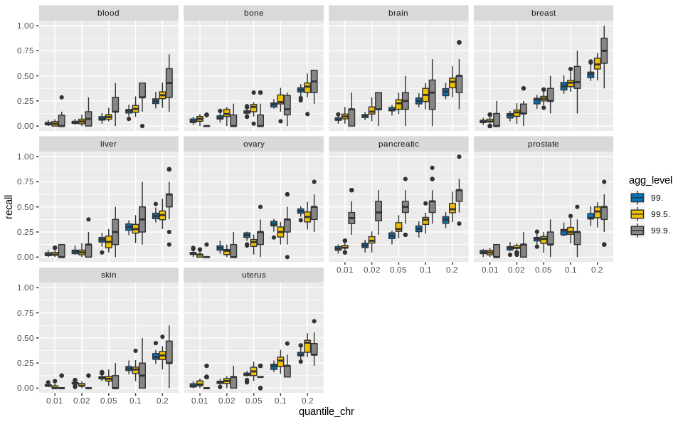

Precision

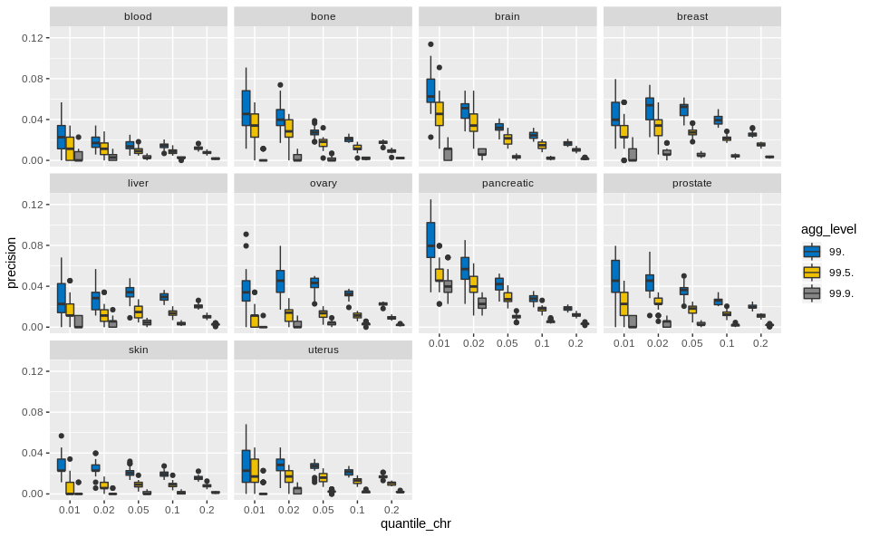

Lift of recall

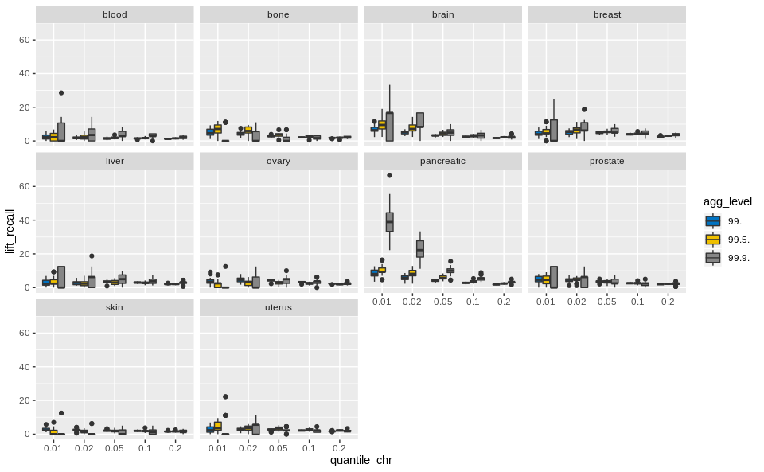

```r
ggplot(all_features_data[all_features_data$quantile_chr %in%
                           c("0.01", "0.02", "0.05", "0.1", "0.2"), ],
       aes(x=quantile_chr, y=lift_recall, fill=agg_level)) +
  geom_boxplot() +
  facet_wrap(~cancer_type) +
  scale_fill_jco()
```

One panel for different probability quantiles

0.005

```r
map_df <- data.frame(agg_level=c("99.", "99.5.", "99.9."), agg_level_num = c(0.01, 0.005, 0.001))
all_features_data <- all_features_data %>%
  inner_join(map_df)
```

```
Column `agg_level` joining character vector and factor, coercing into character vector
```

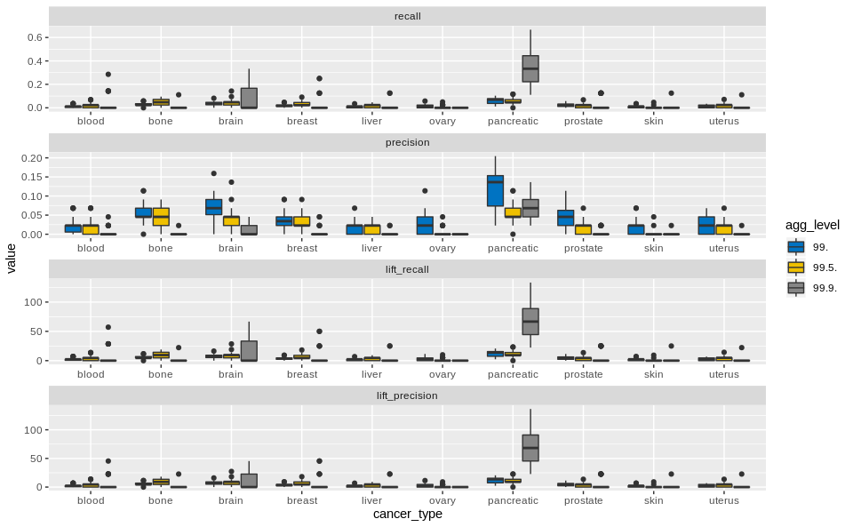

```r
all_features_data$lift_precision <- all_features_data$precision / all_features_data$agg_level_num
comp_rec <- all_features_data %>%
  filter(quantile_chr == "0.005")

comp_rec_pl <- comp_rec %>%
  select('cancer_type', 'agg_level', 'recall', 'precision', 'lift_recall', 'lift_precision') %>%
  melt(id.vars=c("cancer_type","agg_level"))

ggplot(comp_rec_pl, aes(x=cancer_type, y=value, fill=agg_level)) +
  geom_boxplot() +
  facet_wrap(~variable, scales = "free", nrow = 4) +
  scale_fill_jco()
```

0.01

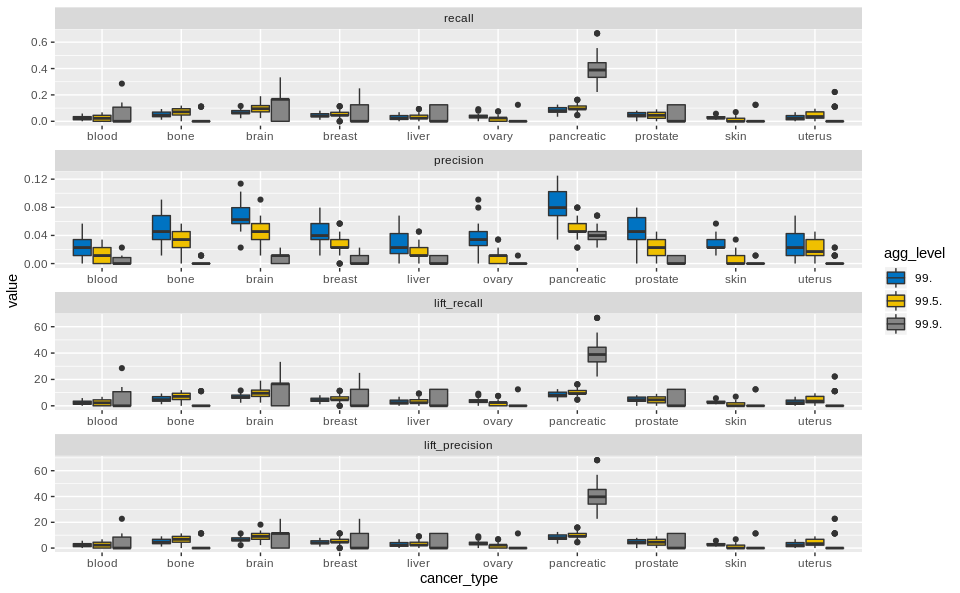

```r
comp_rec <- all_features_data %>%
  filter(quantile_chr == "0.01")

comp_rec_pl <- comp_rec %>%
  select('cancer_type', 'agg_level', 'recall', 'precision', 'lift_recall', 'lift_precision') %>%
  melt(id.vars=c("cancer_type","agg_level"))

ggplot(comp_rec_pl, aes(x=cancer_type, y=value, fill=agg_level)) +
  geom_boxplot() +
  facet_wrap(~variable, scales = "free", nrow = 4) +
  scale_fill_jco()
```

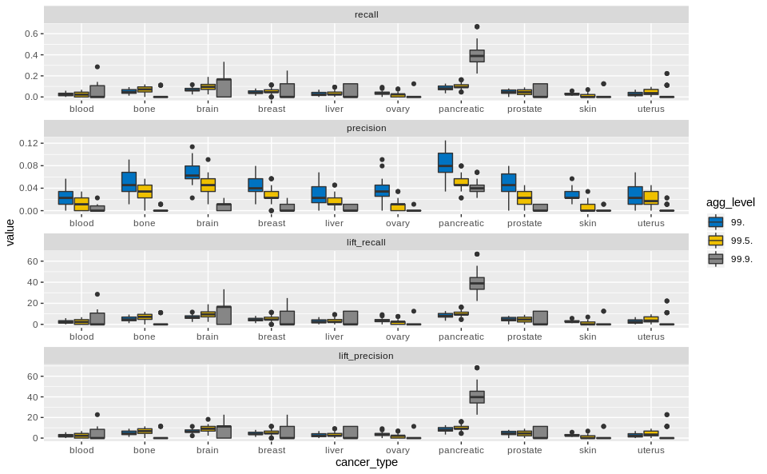

```r
comp_rec <- all_features_data %>%
  filter(quantile_chr == "0.01")
comp_rec_pl <- comp_rec %>%
  select('cancer_type', 'agg_level', 'recall', 'precision', 'lift_recall', 'lift_precision') %>%
  melt(id.vars=c("cancer_type","agg_level"))
ggplot(comp_rec_pl, aes(x=cancer_type, y=value, fill=agg_level)) +
  geom_boxplot() +
  facet_wrap(~variable, scales = "free", nrow = 4) +
  scale_fill_jco()
```

0.03

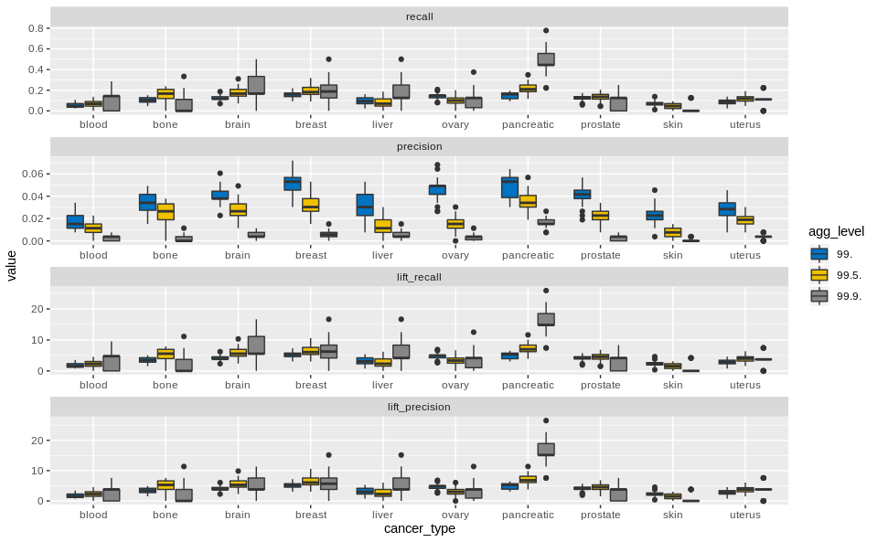

```r
comp_rec <- all_features_data %>%
  filter(quantile_chr == "0.03")

comp_rec_pl <- comp_rec %>%
  select('cancer_type', 'agg_level', 'recall', 'precision', 'lift_recall', 'lift_precision') %>%
  melt(id.vars=c("cancer_type","agg_level"))

ggplot(comp_rec_pl, aes(x=cancer_type, y=value, fill=agg_level)) +
  geom_boxplot() +
  facet_wrap(~variable, scales = "free", nrow = 4) +
  scale_fill_jco()
```

Confidence intervals for lift of recall / recall for different quantiles

```r
ci_stats <- all_features_data %>%
  group_by(cancer_type, agg_level, quantile) %>%
  summarize(
    mean_recall = mean(recall),
    mean_lift_recall = mean(lift_recall),
    mean_precision = mean(precision),
    mean_lift_precision = mean(lift_precision),
    sd_recall = sd(recall),
    sd_lift_recall = sd(lift_recall),
    sd_precision = sd(precision),
    sd_lift_precision = sd(lift_precision),
    n_ex = n()
  ) %>%
  mutate(
    ci_lower_recall = mean_recall - 1.96 * sd_recall / sqrt(n_ex),
    ci_upper_recall = mean_recall + 1.96 * sd_recall / sqrt(n_ex),

    ci_lower_lift_recall = mean_lift_recall - 1.96 * sd_lift_recall / sqrt(n_ex),
    ci_upper_lift_recall = mean_lift_recall + 1.96 * sd_lift_recall / sqrt(n_ex),

    ci_lower_precision = mean_precision - 1.96 * sd_precision / sqrt(n_ex),
    ci_upper_precision = mean_precision + 1.96 * sd_precision / sqrt(n_ex),

    ci_lower_lift_precision = mean_lift_precision - 1.96 * sd_lift_precision / sqrt(n_ex),
    ci_upper_lift_precision = mean_lift_precision + 1.96 * sd_lift_precision / sqrt(n_ex)
  )
```

Lift of recall

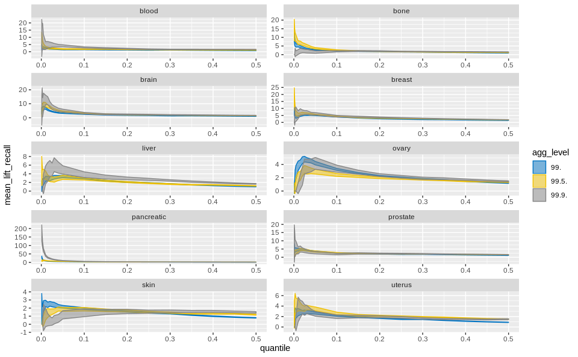

```r
ggplot(ci_stats %>% filter(quantile <= 0.5), aes(x=quantile, y=mean_lift_recall, colour=agg_level)) +
  geom_ribbon(aes(ymin=ci_lower_lift_recall, ymax=ci_upper_lift_recall, fill=agg_level), alpha=0.5) +
  facet_wrap(~ cancer_type, nrow = 5,scales = "free") +
  scale_fill_jco() +
  scale_color_jco()
```

Lift of precision

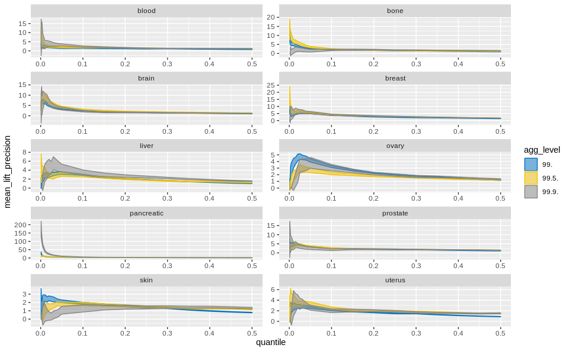

```r
ggplot(ci_stats %>% filter(quantile <= 0.5), aes(x=quantile, y=mean_lift_precision, colour=agg_level)) +
  geom_ribbon(aes(ymin=ci_lower_lift_precision, ymax=ci_upper_lift_precision, fill=agg_level), alpha=0.5) +
  facet_wrap(~ cancer_type, nrow = 5,scales = "free") +
  scale_fill_jco() +
  scale_color_jco()
```

Lift of recall

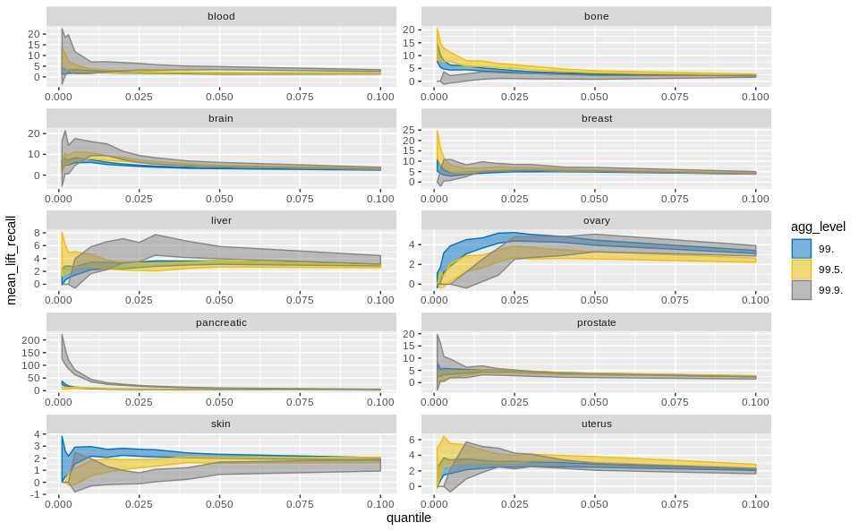

```r
ggplot(ci_stats %>% filter(quantile <= 0.1), aes(x=quantile, y=mean_lift_recall, colour=agg_level)) +
  geom_ribbon(aes(ymin=ci_lower_lift_recall, ymax=ci_upper_lift_recall, fill=agg_level), alpha=0.5) +
  facet_wrap(~ cancer_type, nrow = 5,scales = "free") +
  scale_fill_jco() +
  scale_color_jco()
```

Lift of precision

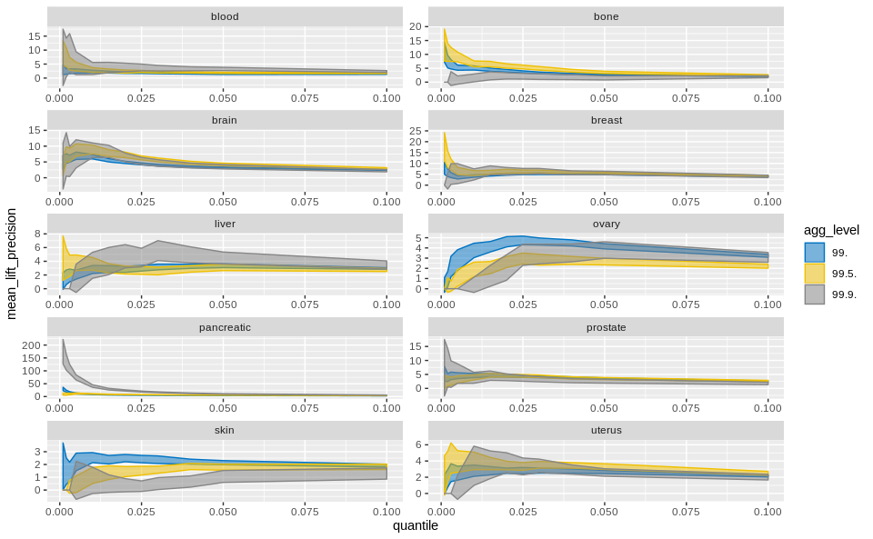

Recall

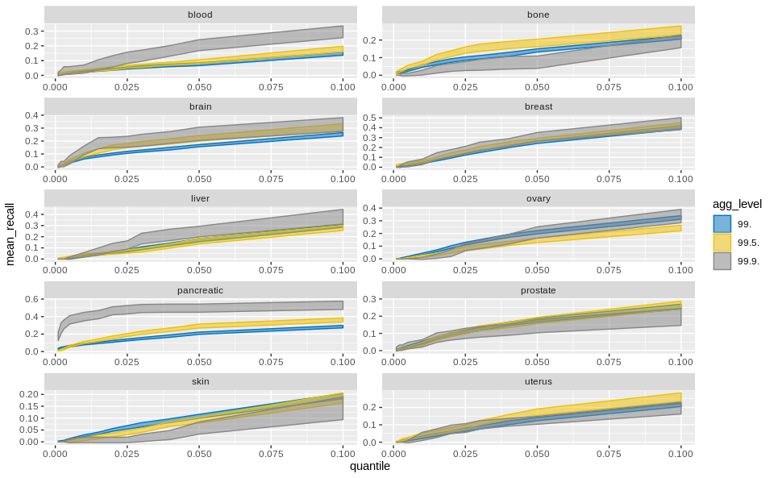

Precision

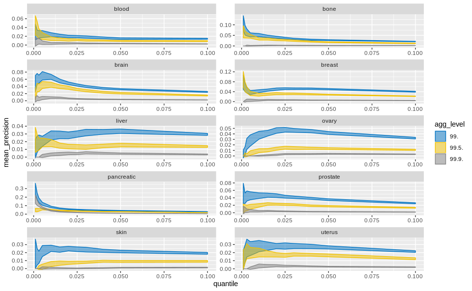

```r
ggplot(ci_stats %>% filter(quantile <= 0.1), aes(x=quantile, y=mean_precision, colour=agg_level)) +
  geom_ribbon(aes(ymin=ci_lower_precision, ymax=ci_upper_precision, fill=agg_level), alpha=0.5) +
  facet_wrap(~ cancer_type, nrow = 5,scales = "free") +
  scale_fill_jco() +
  scale_color_jco()
```

Выводы: судя по приросту полноты и точности нельзя выбрать один тип разметки хотспотов, показывающий максимальное качество по сравнению с остальными для всех типов рака. Так, выделяются три группы типов рака: - для blood, brain, liver, pancreatic cancers лучший тип разметки хотспотов - 99,9% - для bone, breast, uterus cancers лучший тип разметки хотспотов - 99,5% - для ovary, prostate, skin cancers лучший тип разметки хотспотов - 99%

При этом, выделяются следующие особенности: - для breast cancer все три типа разметки хотспотов имеют относительно высокую полноту и минимально отличаются между собой (все три уровня разметки одинако хорошо предсказываются) - для pancreatic cancer тип разметки 99,9 значительно превосходит другие разметки как по приросту полноты, так и по приросту точности.

```r
best_agg_lev_q <- data.frame(
  cancer_type = c('blood', 'brain', 'liver', 'pancreatic', 'bone', 'breast', 'uterus', 'ovary', 'prostate', 'skin'),
  agg_level = c("99.9.","99.9.","99.9.", "99.9.", "99.5.","99.5.", "99.5.", "99.","99.", "99.")
)

best_agg_lev_q %>%
  setNames(c("cancer_type", "agg_level_lift_recall")) %>%
  inner_join(best_lev %>% setNames(c("cancer_type", "agg_level_roc_auc")) , by=c("cancer_type"))
```

| cancer_type | agg_level_lift_recall | agg_level_roc_auc |
| --- | --- | --- |
| blood | 99.9. | 99.5. |
| brain | 99.9. | 99.5. |
| liver | 99.9. | 99. |
| pancreatic | 99.9. | 99.5. |
| bone | 99.5. | 99.5. |
| breast | 99.5. | 99.9. |
| uterus | 99.5. | 99.5. |
| ovary | 99. | 99. |
| prostate | 99. | 99.5. |
| skin | 99. | 99.5. |

Лучший тип разметки, определенный с помощью ROC AUC, совпадает с тем,что определен по приросту полноты и точности, только в трех случаях: для ovary, bone, uterus. Так как оценка точности и полноты при определенных порогах важнее ранжирования, то при выборе итогового лучшего типа разметки хотспотов по типу рака будем использовать лучшее решение, найденное именно по этим параметрам.

Сравним качество для разных типов рака на лучших типах разметки хотспотов

Lift of recall

```
Column `cancer_type` joining character vector and factor, coercing into character vectorColumn `agg_level` joining character vector and factor, coercing into character vector
```

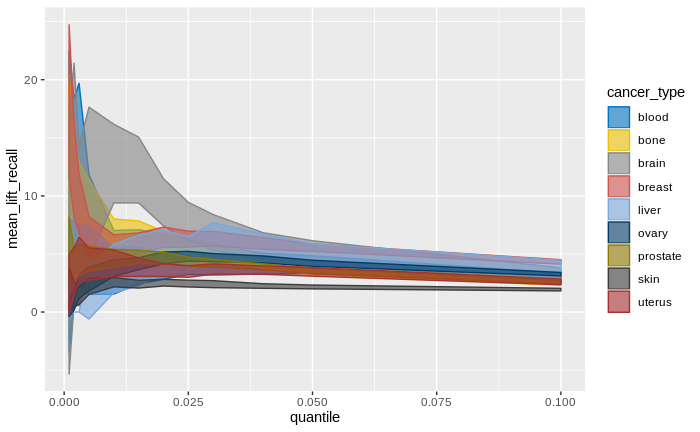

```r
ci_stats %>%
  filter(quantile <= 0.1) %>%
  filter(cancer_type != "pancreatic") %>%
  inner_join(best_agg_lev_q, by=c("cancer_type", "agg_level")) %>%
  ggplot(aes(x=quantile, y=mean_lift_recall, colour=cancer_type)) +
  geom_ribbon(aes(ymin=ci_lower_lift_recall, ymax=ci_upper_lift_recall, fill=cancer_type), alpha=0.6) +
  scale_fill_jco() +
  scale_color_jco()
```

Lift of precision

```
Column `cancer_type` joining character vector and factor, coercing into character vectorColumn `agg_level` joining character vector and factor, coercing into character vector
```

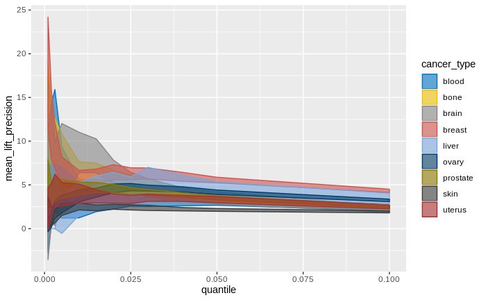

```r
ci_stats %>%
  filter(quantile <= 0.1) %>%
  filter(cancer_type != "pancreatic") %>%
  inner_join(best_agg_lev_q, by=c("cancer_type", "agg_level")) %>%
  ggplot(aes(x=quantile, y=mean_lift_precision, colour=cancer_type)) +
  geom_ribbon(aes(ymin=ci_lower_lift_precision, ymax=ci_upper_lift_precision, fill=cancer_type), alpha=0.6) +
  scale_fill_jco() +
  scale_color_jco()
```

Stats

```r
recall_best_hsp <- recall_data %>%
  filter(feat_group == "all") %>%
  inner_join(best_agg_lev_q, by=c("cancer_type", "agg_level"))
```

```
Column `cancer_type` joining character vector and factor, coercing into character vectorColumn `agg_level` joining character vector and factor, coercing into character vector
```

```r
st <- ci_stats %>%
  filter(quantile == 0.05) %>%
  inner_join(best_agg_lev_q, by=c("cancer_type", "agg_level")) %>%
  select(cancer_type, agg_level, mean_recall, mean_lift_recall, mean_precision, mean_lift_precision)
```

```
Column `cancer_type` joining character vector and factor, coercing into character vectorColumn `agg_level` joining character vector and factor, coercing into character vector
```

```r
formattable(st, align =c("l", "c","c", "c", "c","c"), list(
  `cancer_type` = formatter("span", style = ~ style(color = "grey", font.weight = "bold")),
  `agg_level` = formatter("span", style = ~ style(color = "grey", font.weight = "bold")),
  `mean_recall`= color_tile('#1E90FF', 'yellow'),
  `mean_lift_recall`= color_tile('#1E90FF', 'yellow'),
  `mean_precision`= color_tile('#1E90FF', 'yellow'),
  `mean_lift_precision`= color_tile('#1E90FF', 'yellow')
))
```

| cancer_type | agg_level | mean_recall | mean_lift_recall | mean_precision | mean_lift_precision |
| --- | --- | --- | --- | --- | --- |
| blood | 99.9. | 0.2047619 | 4.095238 | 0.003264996 | 3.264996 |
| bone | 99.5. | 0.1833333 | 3.666667 | 0.017539863 | 3.507973 |
| brain | 99.9. | 0.2555556 | 5.111111 | 0.003492787 | 3.492787 |
| breast | 99.5. | 0.2772727 | 5.545455 | 0.027790433 | 5.558087 |
| liver | 99.9. | 0.2458333 | 4.916667 | 0.004479879 | 4.479879 |
| ovary | 99. | 0.2099617 | 4.199234 | 0.041609719 | 4.160972 |
| pancreatic | 99.9. | 0.4962963 | 9.925926 | 0.010174639 | 10.174639 |
| prostate | 99. | 0.1770115 | 3.540230 | 0.035079727 | 3.507973 |
| skin | 99. | 0.1080460 | 2.160920 | 0.021412301 | 2.141230 |
| uterus | 99.5. | 0.1730159 | 3.460317 | 0.016552771 | 3.310554 |

#### Выделение всех разрывов

Confidence intervals for lift of recall / recall for different quantiles

```r
recall_all_agg <- recall_all_agg %>%
  inner_join(map_df)
```

```
Column `agg_level` joining character vector and factor, coercing into character vector
```

Lift of recall

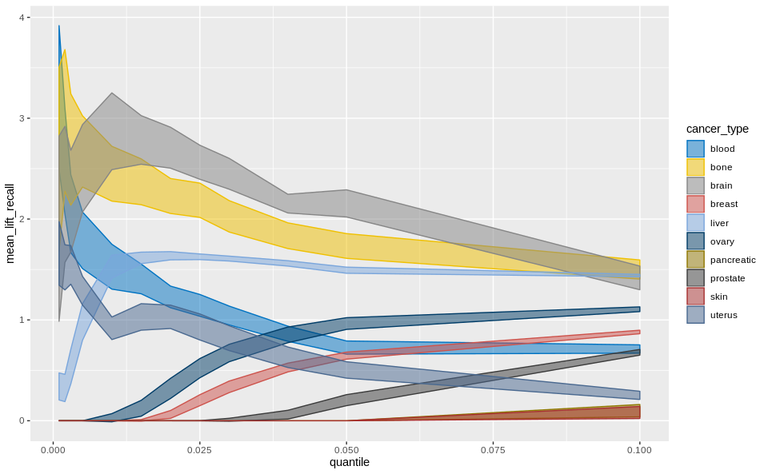

```r
ggplot(ci_stats_bkpt %>% filter(quantile <= 0.1), aes(x=quantile, y=mean_lift_recall, colour=cancer_type)) +
  geom_ribbon(aes(ymin=ci_lower_lift_recall, ymax=ci_upper_lift_recall, fill=cancer_type), alpha=0.5) +
  scale_fill_jco() +
  scale_color_jco()
```

Recall

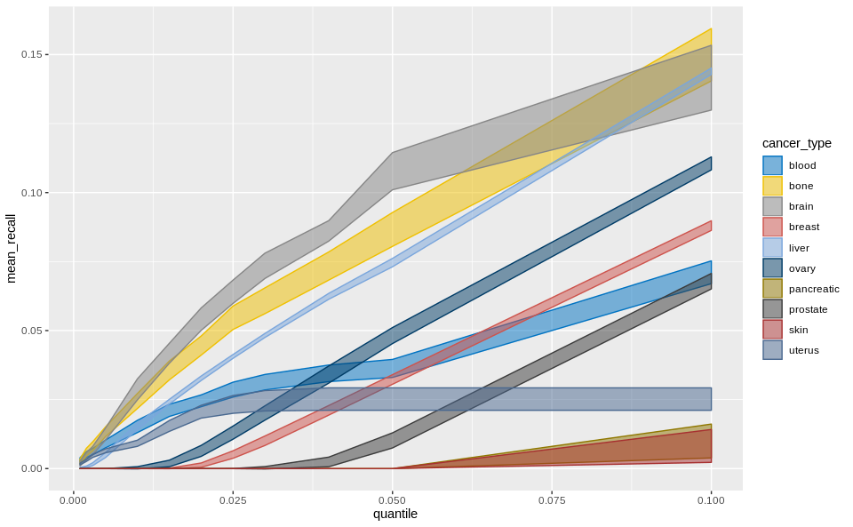

```r
ggplot(ci_stats_bkpt %>% filter(quantile <= 0.1), aes(x=quantile, y=mean_recall, colour=cancer_type)) +
  geom_ribbon(aes(ymin=ci_lower_recall, ymax=ci_upper_recall, fill=cancer_type), alpha=0.5) +
  scale_fill_jco() +
  scale_color_jco()
```

Можно выделить 4 группы типов рака по качеству предсказания разпывов: - pancreatic, skin - очень низкая полнота (не удается распознать разрывы) - ovary, breast, prostate - при маленьких квантилях низкий lift of recall, после возрастает, но на квантили 0,1 lift of recall около 1 - uterus, blood, bone, brain - при маленьких квантилях lift of recall > 1, после падает (для первых двух менее 1, для вторых двух выше 1) - liver - при маленьких квантилях lift of recall возрастает, достигает уовня 1,5 и остается на нем

Предположение: Группа 3 показывает сравнительно более высокое качество, чем остальные, в то время как в целом качество предсказания разрывов намного хуже качества предсказания хотспотов. Возможно, убывающий характер lift of recall говорит о том, что для этих типов рака некоторая доля разрывов является ярко выраженной, а остальная часть также, как и для других типов рака, не выделяется из общей массы. Поэтому, возможно, большее количество размеченных хотспотов может больше соответствовать данным типам рака.